# Biomarkers of Recent Use

## Introduction

This case study investigates the complexities surrounding cannabis-related driving impairment and the challenges of establishing reliable legal thresholds for THC intoxication. Motor vehicle accidents account for about two-thirds of trauma center admissions in the U.S., with cannabis and alcohol most frequently detected in these cases[^1].

While cannabis remains federally illegal, 24 states, including California, have legalized recreational use, which may have led to increased consumption. This shift may have resulted in the increase of cannabis consumption. According to the “Results of the 2007 National Roadside Survey of Alcohol and Drug Use by Drivers”, there was a 25% increase in cannabis use nationwide between 2002 and 2015[^2]. Additionally, the THC detection has increased over time in motor vehicle crashes as the drivers have THC or its related metabolites in their body[^3]. Such increases have brought up concerns over possible impaired driving and related public health risks.

One key challenge in addressing driving under the influence of cannabis (DUIC) is the lack of consistent, reliable cutoffs for THC detection to ensure road safety. As the per se laws indicate, “a driver is deemed to have committed an offense if THC is detected at or about a pre-determined cutoff”[^4]. There are 19 states adopting this law for zero tolerance on cannabis use. Some states set their limit to be 1-5 ng/mL THC cutoffs in whole blood, and some states use this law for both THC and its metabolites[^5]. Additionally, for frequent users, THC concentration remains detectable for longer than the occasional users, and detection in blood of THC and some of its metabolites is not a certain indicator of impairment[^6]. Thus, it is difficult to define cutoffs for safe driving and select appropriate compounds for gauging impairment. This is due to various factors that influence the THC concentration, such as the smoking situation regarding the time and number of puffs, frequency of use, and method of consumption.

Given these complexities, this case study aims to explore a biomarker that could best indicate recent cannabis use and impairment, along with an extended exploration on the difference between frequent users and occasional users.

## Questions

1. Which compound, in which matrix, and at what cutoff is the best biomarker of recent use?
2. What different cutoff thresholds can be established for frequent users versus occasional users to accurately gauge impairment?

### Load packages

```r
library(tidyverse)
library(dplyr)
library(patchwork)
```

## The Data

This analysis is based on data from a study by Hubbard et al. (2021) titled “Biomarkers of Recent Cannabis Use in Blood, Oral Fluid, and Breath” published in the Journal of Analytical Toxicology[^7]. Conducted by Professor Rob Fitzgerald’s research group, this placebo-controlled, double-blinded, and randomized study investigated whether cannabinoid concentrations in whole blood (WB), oral fluid (OF), or breath could identify use within the timeframe of 3 hours, which is the period of the greatest impairment. After exclusion of participants that their oral fluid’s THC concentration is equal to or greater than 5 ng/mL on day of study (n=7), there were 191 volunteers (age 21 - 55) in the study with compensation, and all of them had a valid driver license and self-reported using cannabis at least 4 times in the past month. The participants were classified with two groups: frequent user and occasional user, where frequent user is defined as smoking cannabis 4 weeks or more, and occasional user is defined as smoking cannabis less than 4 weeks.

During the experiment, they were randomly assigned to three treatments receiving a cigarette: placebo (0.02% THC), 5.9% THC, and 13.4% THC. Each group was balanced with approximately equal numbers of frequent and occasional users. Participants were instructed to smoke a 700 mg cigarette ad libitum within 10 minutes, with a minimum requirement of four puffs. Blood, oral fluid, and breath collections were collected prior to smoking to establish baseline measurements. After smoking consumption, there were 4 additional oral fluid and breath collections, and 8 blood collections were completed within the 6 hours from the start of smoking. There were four driving simulations conducted at four intervals: 26, 96, 211, and 273 minutes after smoking. Participants were allowed to eat and drink water between collections, but not within 10 min of oral fluid collection.

### Data Import

First, we read each of the 3 CSV files (whole blood, oral fluid, breath) and make individual dataframes.

```r
WB <- read_csv("data/Blood.csv")
BR <- read_csv("data/Breath.csv")
OF <- read_csv("data/OF.csv")
```

### Data Wrangling

```r
# mutating 'treatment' column values & renaming columns.
WB <- WB |>
  mutate(Treatment = fct_recode(Treatment,
                                "5.9% THC (low dose)" = "5.90%",
                                "13.4% THC (high dose)" = "13.40%"),
         Treatment = fct_relevel(Treatment, "Placebo", "5.9% THC (low dose)")) |>
  janitor::clean_names() |>
  rename(thcoh = x11_oh_thc,
         thccooh = thc_cooh,
         thccooh_gluc = thc_cooh_gluc,
         thcv = thc_v)

# mutating 'time_from_start' column to be a range instead of a value
WB <- WB |>
  mutate(timepoint = case_when(time_from_start < 0 ~ "pre-smoking",
           time_from_start > 0 & time_from_start <= 30 ~ "0-30 min",
           time_from_start > 30 & time_from_start <= 90 ~ "31-90 min",
           time_from_start > 90 & time_from_start <= 180 ~ "91-180 min",
           time_from_start > 180 & time_from_start <= 210 ~ "181-210 min",
           time_from_start > 210 & time_from_start <= 240 ~ "211-240 min",
           time_from_start > 240 & time_from_start <= 270 ~ "241-270 min",
           time_from_start > 270 ~ "271+ min"
   ))
```

Now, we will wrangle & clean the oral fluid dataframe. Similar to the whole blood dataframe, we will re-code and re-level ‘treatment’. We will also clean & rename certain columns.

```r
# treatment re-coded and re-leveled; col names modified
OF <- OF |>
  mutate(Treatment = fct_recode(Treatment,
                                "5.9% THC (low dose)" = "5.90%",
                                "13.4% THC (high dose)" = "13.40%"),
         Treatment = fct_relevel(Treatment, "Placebo", "5.9% THC (low dose)")) |>
  janitor::clean_names() |>
  rename(thcoh = x11_oh_thc,
         thcv = thc_v,
         fluid_type=fluid)

# transforming values
OF <- OF |>
  mutate(timepoint = case_when(time_from_start < 0 ~ "pre-smoking",
           time_from_start > 0 & time_from_start <= 30 ~ "0-30 min",
           time_from_start > 30 & time_from_start <= 90 ~ "31-90 min",
           time_from_start > 90 & time_from_start <= 180 ~ "91-180 min",
           time_from_start > 180 & time_from_start <= 210 ~ "181-210 min",
           time_from_start > 210 & time_from_start <= 240 ~ "211-240 min",
           time_from_start > 240 & time_from_start <= 270 ~ "241-270 min",
           time_from_start > 270 ~ "271+ min"
   ))
```

Next, we will transform the breath dataframe in a similar fashion as the previous two.

```r
# treatment re-coded and re-leveled; col names modified
BR <- BR |>
  mutate(Treatment = fct_recode(Treatment,
                                "5.9% THC (low dose)" = "5.90%",
                                "13.4% THC (high dose)" = "13.40%"),
         Treatment = fct_relevel(Treatment, "Placebo", "5.9% THC (low dose)")) |>
  janitor::clean_names() |>
  rename(thc = thc_pg_pad,
         fluid_type=fluid)

# transforming values
BR <- BR |>
  mutate(timepoint = case_when(time_from_start < 0 ~ "pre-smoking",
           time_from_start > 0 & time_from_start <= 40 ~ "0-40 min",
           time_from_start > 40 & time_from_start <= 90 ~ "41-90 min",
           time_from_start > 90 & time_from_start <= 180 ~ "91-180 min",
           time_from_start > 180 & time_from_start <= 210 ~ "181-210 min",
           time_from_start > 210 & time_from_start <= 240 ~ "211-240 min",
           time_from_start > 240 & time_from_start <= 270 ~ "241-270 min",
           time_from_start > 270 ~ "271+ min"
   ))
```

Finally, we will combine all of our dataframes into one, then write that combination to a CSV file. Then, we will pivot the data to make ‘compound’ a column with a corresponding ’value’column.

```r
combined_csv <- bind_rows(WB, BR, OF)
combined_csv <- combined_csv |>
  select(1:5,time_from_start,everything()) |>
  pivot_longer(7:15)

combined_csv <- combined_csv %>%
  rename(compound = name)

head(combined_csv)
```

```
## # A tibble: 6 × 8
##   id    treatment      group fluid_type timepoint time_from_start compound value
##   <chr> <fct>          <chr> <chr>      <chr>               <dbl> <chr>    <dbl>
## 1 11255 5.9% THC (low… Occa… WB         pre-smok…             -27 cbn        0
## 2 11255 5.9% THC (low… Occa… WB         pre-smok…             -27 cbd        0
## 3 11255 5.9% THC (low… Occa… WB         pre-smok…             -27 thc        0.5
## 4 11255 5.9% THC (low… Occa… WB         pre-smok…             -27 thcoh      0
## 5 11255 5.9% THC (low… Occa… WB         pre-smok…             -27 thccooh    5.7
## 6 11255 5.9% THC (low… Occa… WB         pre-smok…             -27 thccooh…   4.9
```

```r
combined_csv
```

```
## # A tibble: 30,843 × 8
##    id    treatment     group fluid_type timepoint time_from_start compound value
##    <chr> <fct>         <chr> <chr>      <chr>               <dbl> <chr>    <dbl>
##  1 11255 5.9% THC (lo… Occa… WB         pre-smok…             -27 cbn        0
##  2 11255 5.9% THC (lo… Occa… WB         pre-smok…             -27 cbd        0
##  3 11255 5.9% THC (lo… Occa… WB         pre-smok…             -27 thc        0.5
##  4 11255 5.9% THC (lo… Occa… WB         pre-smok…             -27 thcoh      0
##  5 11255 5.9% THC (lo… Occa… WB         pre-smok…             -27 thccooh    5.7
##  6 11255 5.9% THC (lo… Occa… WB         pre-smok…             -27 thccooh…   4.9
##  7 11255 5.9% THC (lo… Occa… WB         pre-smok…             -27 cbg        0
##  8 11255 5.9% THC (lo… Occa… WB         pre-smok…             -27 thcv       0
##  9 11255 5.9% THC (lo… Occa… WB         pre-smok…             -27 thca_a    NA
## 10 11255 5.9% THC (lo… Occa… WB         0-30 min               15 cbn        2.8
## # ℹ 30,833 more rows
```

Before we start doing any analysis, we also need to handle all the missing entries in the ‘value’ column.

```r
combined_csv<-combined_csv %>% filter(!is.na(value))
combined_csv
```

```
## # A tibble: 19,785 × 8
##    id    treatment     group fluid_type timepoint time_from_start compound value
##    <chr> <fct>         <chr> <chr>      <chr>               <dbl> <chr>    <dbl>
##  1 11255 5.9% THC (lo… Occa… WB         pre-smok…             -27 cbn        0
##  2 11255 5.9% THC (lo… Occa… WB         pre-smok…             -27 cbd        0
##  3 11255 5.9% THC (lo… Occa… WB         pre-smok…             -27 thc        0.5
##  4 11255 5.9% THC (lo… Occa… WB         pre-smok…             -27 thcoh      0
##  5 11255 5.9% THC (lo… Occa… WB         pre-smok…             -27 thccooh    5.7
##  6 11255 5.9% THC (lo… Occa… WB         pre-smok…             -27 thccooh…   4.9
##  7 11255 5.9% THC (lo… Occa… WB         pre-smok…             -27 cbg        0
##  8 11255 5.9% THC (lo… Occa… WB         pre-smok…             -27 thcv       0
##  9 11255 5.9% THC (lo… Occa… WB         0-30 min               15 cbn        2.8
## 10 11255 5.9% THC (lo… Occa… WB         0-30 min               15 cbd        0
## # ℹ 19,775 more rows
```

## Analysis

We want to check the general trend of the compounds across time. The trends are grouped by treatment group because we expect that the values of a certain compound should increase from the placebo to the 5.9% dosage to the 13.4% dosage. Additionally, we should expect that compounds should not change significantly change value for the placebo users.

Below is a function that will plot all of the compounds for a given fluid type (provided through the matrix parameter). Notably, we are using geom_smooth() with the loess method. This allows us to get a trend line that predicts using local data. ‘Span’ is the other parameter which specifies how large a range the trend line will be calculated from. We made this a parameter when we realized that the different matrices needed to be customized. This provides a more accurate ‘average’ overview that is much clearer than a normal lineplot. The other advantage of using this method is that we can see the variability of the data throughout the trend. If the shaded region is smaller, we know that the trend has been captured quite well.

```r
plot_line_time <- function(matrix, span) {
  combined_csv |>
      filter(!is.na(time_from_start), fluid_type==matrix) |>
      ggplot(aes(x=time_from_start, y=value, color=treatment)) +
        geom_smooth(method = "loess", span = span) +
        facet_wrap(~compound, scales="free") +
        scale_color_manual(values=c("#FF9108", "#B692F7", "#84AFE6")) +
        theme_classic() +
        labs(title = paste("Measured Compounds in", matrix, "Over Time"),
             x="Time From Start (min)") +
        theme(legend.position="bottom",
              legend.title=element_blank(),
              strip.background=element_blank(),
              plot.title.position="plot")
}
```

Using our function, let’s look at whole blood.

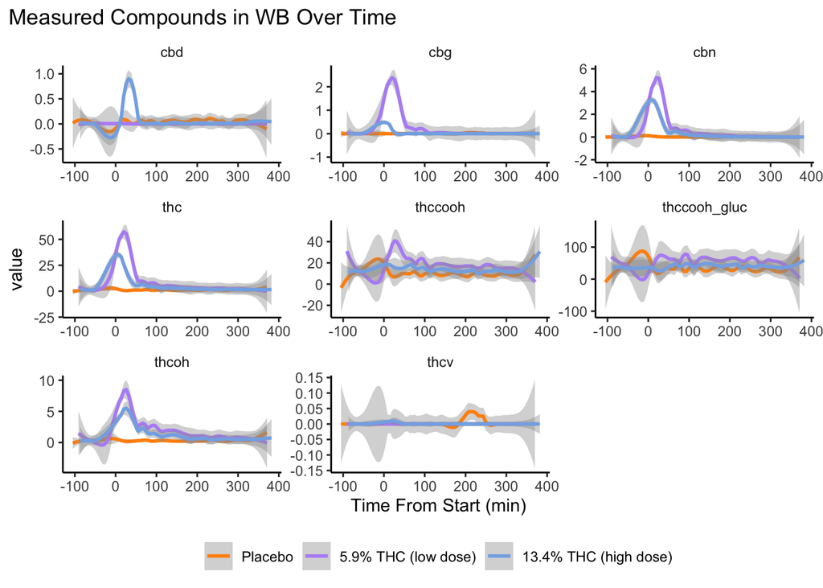

```r
plot_line_time(matrix="WB", span=0.2)
```

Now, let’s look at breath.

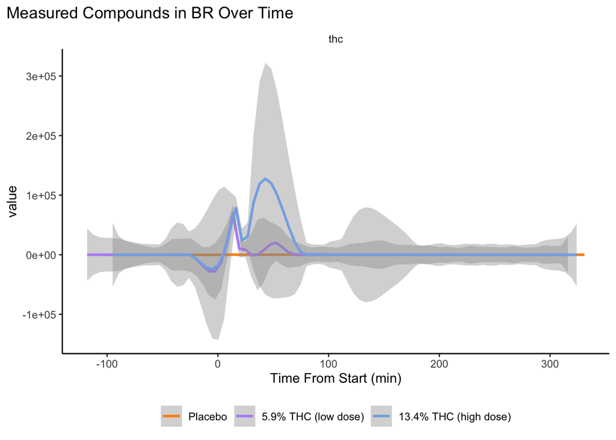

```r
plot_line_time(matrix="BR", span=0.1)
```

There is only one compound that can be measured from breath, and that is THC. This compound actually *does* follow our predicted trend; this is definitely worth pursuing more analysis. We might notice that that the distribution seems to be bimodal, but this is just a consequence of the geom_smooth() method. For that reason, we lowered the span for these generated graphs.

Finally, let’s look at oral fluid.

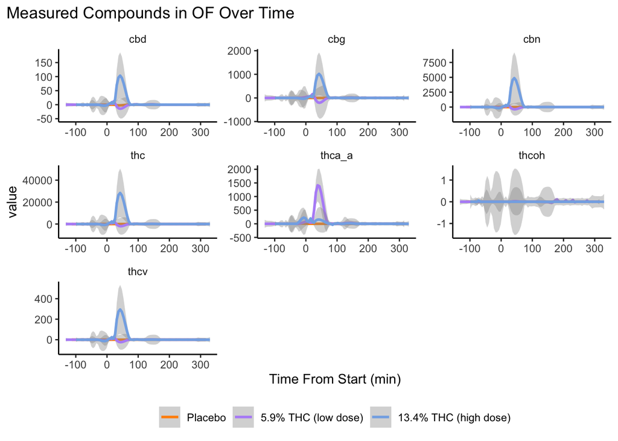

```r
plot_line_time(matrix="OF", span=0.05)
```

With all the above analysis, we could draw a rough conclusion that the worth-exploring compounds include CBN,THC and THCOH in Whole Blood, THC in Breath plus THCV and THC in the oral fluid.

This analysis aims to answer the main question that is ‘which compounds, in which matrices (fluid types), and at what cutoff levels serve as the best biomarker for recent cannabis use’. We achieve this by analyzing sensitivity (the ability to correctly detect true positives) and specificity (the ability to correctly detect true negatives) at various threshold levels for each compound and matrix combination. An ideal biomarker will have a balance of both high sensitivity and specificity.However, in our analysis, we decide to prioritize the specificity over sensitivity. Positive roadside tests are often confirmed with more sensitive lab-based tests. By focusing on specificity at the roadside level, authorities can minimize unnecessary detainment or inconvenience, while lab tests can verify impairment levels more accurately. Thus, our goal is to find the cutoff that optimize the specificity while keeping a reasonable sensitivity level.

The code chunk below is a function that computes specificity, sensitivity, and other metrics based on a dataset, cutoff values, compound, and timepoint.

```r
make_calculations <- function(dataset, cutoff, compound, timepoint_use, group){
  df <- dataset |>
    select(treatment, {{ compound }}, timepoint, group) |>
    filter(timepoint == timepoint_use, group == group, !is.na({{ compound }}))

  if(nrow(df)>0){
    if(timepoint_use == "pre-smoking"){
      output <- df |>
        summarize(TP = 0,
                  FN = 0,
                  FP = sum(!!sym(compound) >= cutoff),
                  TN = sum(!!sym(compound) < cutoff))
    }else{
      if(cutoff == 0){
        output_pre <- df |>
          filter(timepoint_use == "pre-smoking") |>
          summarize(TP = 0,
                    FN = 0,
                    FP = sum(!!sym(compound) >= cutoff),
                    TN = sum(!!sym(compound) < cutoff))

        output <- df |>
          filter(timepoint_use != "pre-smoking") |>
          summarize(TP = sum(treatment != "Placebo" & !!sym(compound) > cutoff),
                    FN = sum(treatment != "Placebo" & !!sym(compound) <= cutoff),
                    FP = sum(treatment == "Placebo" & !!sym(compound) > cutoff),
                    TN = sum(treatment == "Placebo" & !!sym(compound) < cutoff))

        output <- output + output_pre
      }else{
        output_pre <- df |>
          filter(timepoint_use == "pre-smoking") |>
          summarise(TP = 0,
                    FN = 0,
                    FP = sum(!!sym(compound) >= cutoff),
                    TN = sum(!!sym(compound) < cutoff))

        output <- df |>
          filter(timepoint_use != "pre-smoking") |>
          summarise(TP = sum(treatment != "Placebo" & !!sym(compound) >= cutoff),
                    FN = sum(treatment != "Placebo" & !!sym(compound) < cutoff),
                    FP = sum(treatment == "Placebo" & !!sym(compound) >= cutoff),
                    TN = sum(treatment == "Placebo" & !!sym(compound) < cutoff))

        output <- output + output_pre
      }
    }

  output <- output |>
    mutate(detection_limit = cutoff,
           compound = compound,
           time_window = timepoint_use,
           group = group,
           NAs = nrow(dataset) - nrow(df),
           N = nrow(dataset),
           Sensitivity = (TP/(TP + FN)),
           Specificity = (TN /(TN + FP)),
           Youden_J = Sensitivity + Specificity - 1,
           PPV = (TP/(TP+FP)),
           NPV = (TN/(TN + FN)),
           Efficiency = ((TP + TN)/(TP + TN + FP + FN))*100
    )
  return(output)
}
}

sens_spec_cpd <- function(dataset, cpd, timepoints){
  args2 <- list(start = timepoints$start,
                stop = timepoints$stop,
                tpt_use = timepoints$timepoint)
  out <- args2 |>
    pmap_dfr(make_calculations, dataset, compound = cpd)
  return(out)
}
```

For each potential possible biomarkers, we’ll use various cutoff levels to classify samples as recent use or not. We’ll calculate sensitivity and specificity at each cutoff and plot the results out.

First of all, we will calculate performance metrics (Sensitivity and Specificity) for multiple compounds across different cutoff levels and timepoints in whole blood samples. Below is a function that will return a comprehensive dataset that contains the metrics for each combination of cutoff, compound, and timepoint.

```r
cs_data<-bind_rows(WB, BR, OF)
# specify which calculations to make
cutoffs <- c(0.5, 1, 2,5, 10)
compounds <- combined_csv |> filter(fluid_type=="WB") |> filter(!is.na(value)) |> distinct(compound) |> pull(compound)
WB_timepoints <- c("pre-smoking","0-30 min","31-70 min", "71-100 min","101-180 min","181-210 min", "211-240 min","241-270 min", "271-300 min", "301+ min")
WB <- cs_data |> filter(fluid_type=="WB")

# Specify all parameter combinations
param_grid <- expand.grid(
  cutoffs = cutoffs,
  compounds = compounds,
  timepoint_use = WB_timepoints,
  group = unique(WB$group)
)


# Calculate for all cutoff-compound-timepoint combinations
WB_ss <- purrr::pmap_dfr(param_grid, ~ make_calculations(dataset=WB, cutoff = ..1, compound = as.character(..2), timepoint_use = ..3, group = ..4))

WB_ss
```

```
## # A tibble: 400 × 16
##       TP    FN    FP    TN detection_limit compound time_window group        NAs
##    <dbl> <dbl> <int> <int>           <dbl> <chr>    <fct>       <fct>      <int>
##  1     0     0     1   188             0.5 cbn      pre-smoking Occasiona…  1336
##  2     0     0     0   189             1   cbn      pre-smoking Occasiona…  1336
##  3     0     0     0   189             2   cbn      pre-smoking Occasiona…  1336
##  4     0     0     0   189             5   cbn      pre-smoking Occasiona…  1336
##  5     0     0     0   189            10   cbn      pre-smoking Occasiona…  1336
##  6     0     0     4   185             0.5 cbd      pre-smoking Occasiona…  1336
##  7     0     0     1   188             1   cbd      pre-smoking Occasiona…  1336
##  8     0     0     1   188             2   cbd      pre-smoking Occasiona…  1336
##  9     0     0     0   189             5   cbd      pre-smoking Occasiona…  1336
## 10     0     0     0   189            10   cbd      pre-smoking Occasiona…  1336
## # ℹ 390 more rows
## # ℹ 7 more variables: N <int>, Sensitivity <dbl>, Specificity <dbl>,
## #   Youden_J <dbl>, PPV <dbl>, NPV <dbl>, Efficiency <dbl>
```

Below is a function designed to visualize the performance metrics (Sensitivity and Specificity) of a specified compound across different time windows and cutoff levels:

```r
plot_cutoffs <- function(dataset, timepoint_use_variable, tissue, cpd){
    # control colors and lines used in plots
    col_val = c("#003f5c", "#58508d", "#bc5090", "#ff6361", "#ffa600")
    lines = rep("solid", 5)

    # prep data
    df_ss <- dataset |>
      filter(compound == cpd) |>
      mutate(time_window = fct_relevel(as.factor(time_window), levels(timepoint_use_variable)),
             detection_limit = as.factor(detection_limit),
             Sensitivity =  round(Sensitivity*100, 0),
             Specificity =  round(Specificity*100, 0),
            Youden_J = Sensitivity + Specificity - 100)

    # plot sensitivity
    p1 <- df_ss |>
      ggplot(aes(x = time_window, y = Sensitivity,
                 color = detection_limit)) +
      geom_line(linewidth = 1.2, aes(group = detection_limit,
                                linetype = detection_limit)) +
      geom_point(show.legend=FALSE) +
      ylim(0,100) +
      scale_x_discrete(labels = function(x) str_wrap(x, width = 5)) +
      scale_linetype_manual(values=lines) +
      scale_color_manual(values = col_val, name = "Cutoff \n (ng/mL)",
                        guide = guide_legend(override.aes = list(linetype = c(1),
                        shape = rep(NA, length(lines))) )) +
      theme_classic() +
      theme(plot.title.position = "plot",
            axis.title = element_text(size=14),
            axis.text = element_text(size=10),
            axis.text.x = element_text(angle = 45, hjust = 1),
            legend.position = "none",
            panel.grid = element_blank(),
            strip.background = element_blank()
            ) +
      guides(linetype = "none") +
      labs(x = "Time Window (min)",
           y = "Sensitivity",
           title = paste0(tissue,": ", toupper(cpd)) )

  # plot specificity
  p2 <- df_ss |>
      ggplot(aes(x = time_window, y = Specificity,
                 group = detection_limit,
                 color = detection_limit,
                 linetype = detection_limit)) +
      geom_line(linewidth = 1.2) +
      geom_point() +
      ylim(0,100) +
      scale_color_manual(values = col_val) +
      scale_x_discrete(labels = function(x) str_wrap(x, width = 5)) +
      scale_linetype_manual(values = lines,
                            guide = guide_legend(override.aes = list(linetype = "solid",
                                                                     shape = rep(NA, length(lines))) )) +
      theme_classic() +
      theme(axis.title = element_text(size=14),
            axis.text = element_text(size=10),
            axis.text.x = element_text(angle = 45, hjust = 1),
            legend.position = c(0.35, 0.25),
            panel.grid = element_blank(),
            strip.background = element_blank()) +
      labs(x = "Time Window",
           y = "Specificity",
           title = "" )

  # combine plots (uses patchwork)
  p1 + p2

}
```

Let’s first visualize the THC’s performance metrics in the whole blood:

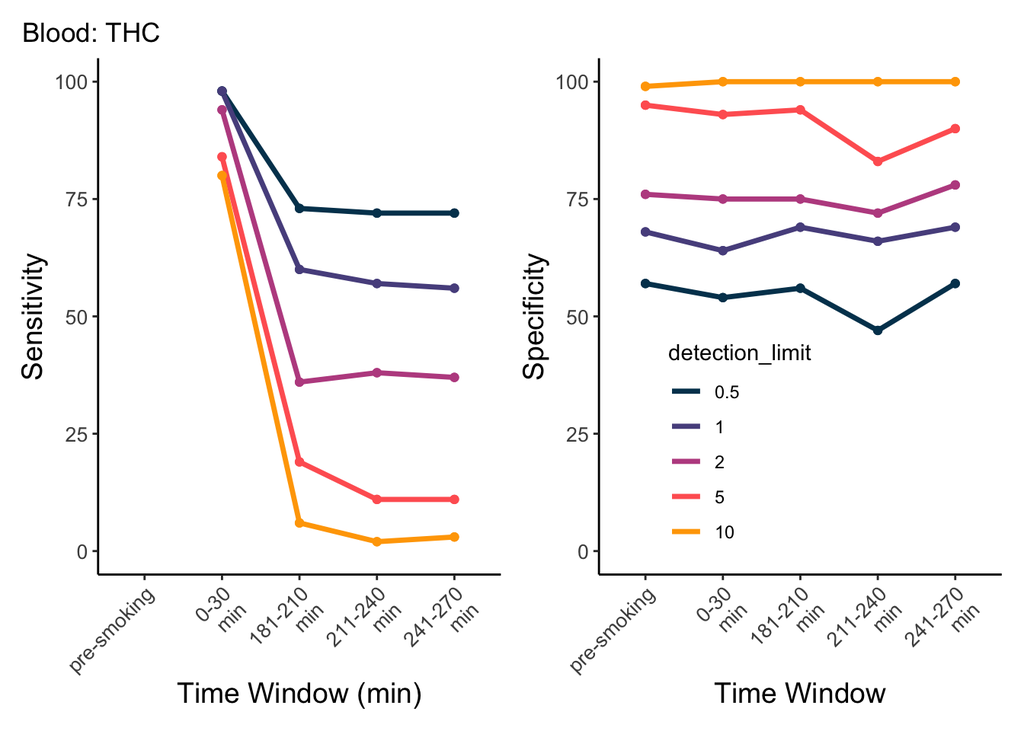

```r
plot_cutoffs(dataset=WB_ss,
             timepoint_use_variable=WB$timepoint,
             tissue="Blood",
             cpd="thc")
```

Next,let’s visualize CBN’s performance in the whole blood across time:

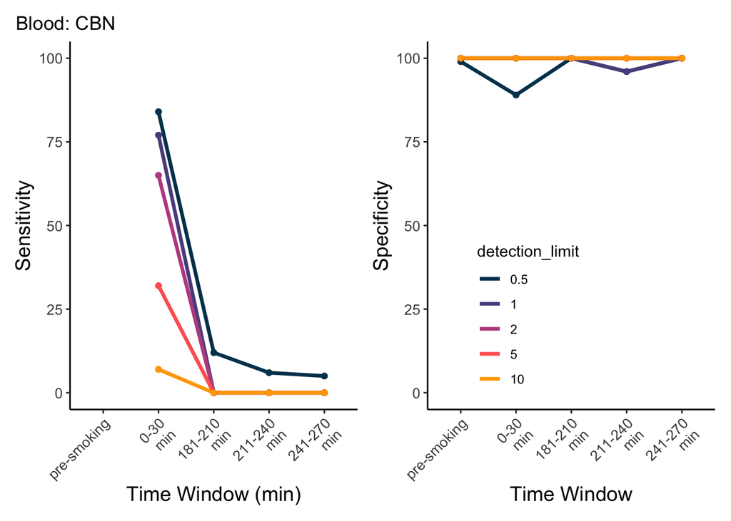

```r
plot_cutoffs(dataset=WB_ss,
             timepoint_use_variable=WB$timepoint,
             tissue="Blood",
             cpd="cbn")
```

Sensitivity starts relatively high at the initial time windows but drops sharply to near zero within a few hours post-smoking.

This pattern is seen across all cutoff levels, with no cutoff level providing significant sensitivity beyond the initial time window.This rapid decline suggests that CBN is detectable in blood only shortly after smoking and that its levels fall quickly, making it difficult to detect as time progresses. On the other hand, specificity remains consistently high (near 100%) across all time windows and cutoff levels. This tells us that false positives for CBN are rare in this dataset, which implies that any detected CBN is likely a true positive.

Let’s also take a look at THCOH’s performance in the whole blood:

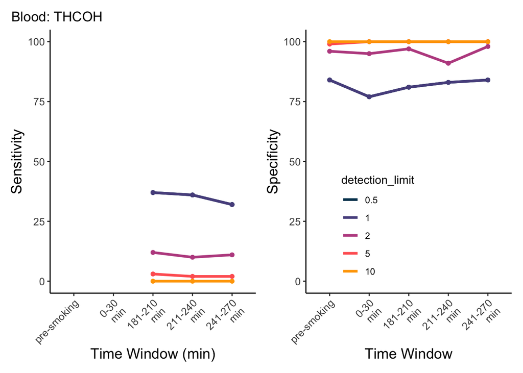

```r
plot_cutoffs(dataset=WB_ss,
             timepoint_use_variable=WB$timepoint,
             tissue="Blood",
             cpd="thcoh")
```

In a conclusion, for all potential biomarker compounds in the whole blood, THC is the best biomarker among the three if we want to prioritize specificity while maintaining a reasonable sensitivity level. It has the highest initial sensitivity and retains reasonable detectability over multiple time windows, especially at lower cutoff levels. For THC detection in blood, 5 ng/mL is likely the best cutoff. This cutoff effectively minimizes false positives, ensuring that individuals who test positive are more likely to have significant, recent THC levels that may indicate impairment. This threshold reduces the likelihood of capturing low, residual THC levels that could linger in the bloodstream without contributing to impairment, which is particularly valuable in legal and roadside testing contexts.

Below is a dataframe that contains the performance metrics (Sensitivity and Specificity) for multiple compounds across different cutoff levels and timepoints in oral fluid samples:

```r
cutoffs <- c(0.5, 1, 2, 5, 10)
compounds <- combined_csv |> filter(fluid_type=="OF") |> filter(!is.na(value)) |> distinct(compound) |> pull(compound)
OF_timepoints <- c("pre-smoking","0-30 min","31-90 min",
                   "91-180 min", "181-210 min", "211-240 min",
                   "241-270 min", "271+ min")
OF <- cs_data |> filter(fluid_type=="OF")

# Specify all parameter combinations
param_grid <- expand.grid(
  cutoffs = cutoffs,
  compounds = compounds,
  timepoint_use = OF_timepoints,
  group = unique(OF$group)
)

# Calculate for all cutoff-compound-timepoint combinations
OF_ss <- purrr::pmap_dfr(param_grid, ~ make_calculations(
  dataset = OF,
  cutoff = ..1,
  compound = as.character(..2),
  timepoint_use = ..3,
  group = ..4
))

 OF_ss
```

```
## # A tibble: 560 × 16
##       TP    FN    FP    TN detection_limit compound time_window group        NAs
##    <dbl> <dbl> <int> <int>           <dbl> <chr>    <fct>       <fct>      <int>
##  1     0     0     5   187             0.5 cbn      pre-smoking Not exper…   761
##  2     0     0     1   191             1   cbn      pre-smoking Not exper…   761
##  3     0     0     1   191             2   cbn      pre-smoking Not exper…   761
##  4     0     0     1   191             5   cbn      pre-smoking Not exper…   761
##  5     0     0     0   192            10   cbn      pre-smoking Not exper…   761
##  6     0     0     4   188             0.5 cbd      pre-smoking Not exper…   761
##  7     0     0     1   191             1   cbd      pre-smoking Not exper…   761
##  8     0     0     1   191             2   cbd      pre-smoking Not exper…   761
##  9     0     0     0   192             5   cbd      pre-smoking Not exper…   761
## 10     0     0     0   192            10   cbd      pre-smoking Not exper…   761
## # ℹ 550 more rows
## # ℹ 7 more variables: N <int>, Sensitivity <dbl>, Specificity <dbl>,
## #   Youden_J <dbl>, PPV <dbl>, NPV <dbl>, Efficiency <dbl>
```

Let’s take a look at the THC’s performance in Oral Fluid:

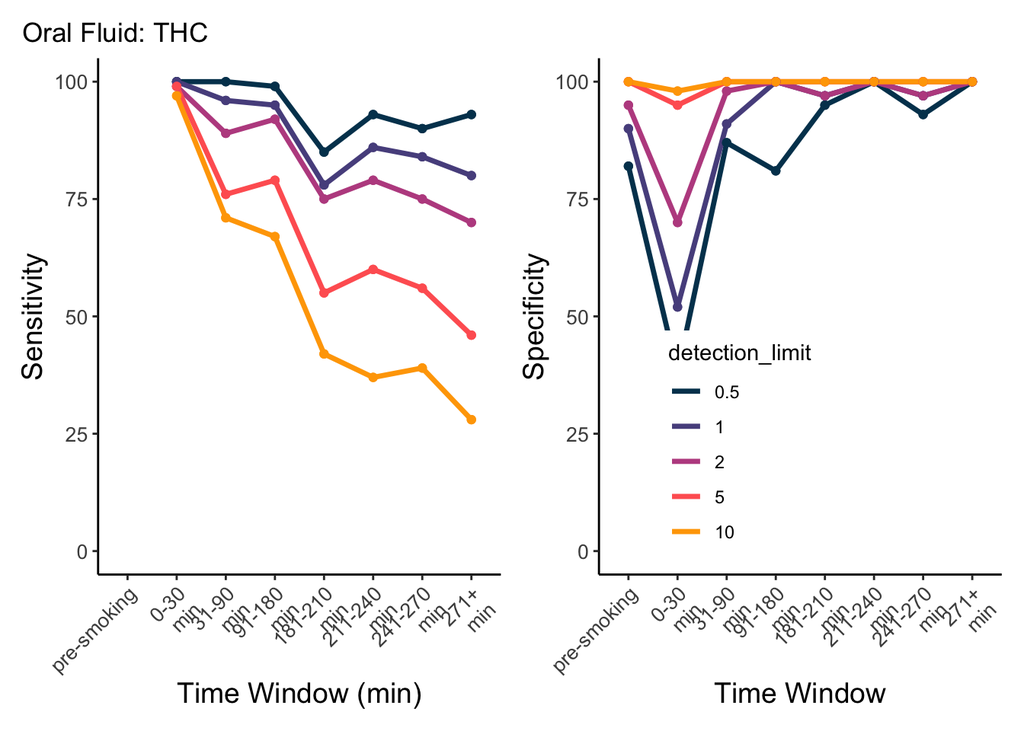

```r
plot_cutoffs(dataset=OF_ss,
             timepoint_use_variable=OF$timepoint,
             tissue="Oral Fluid",
             cpd="thc")
```

Performance of THCV in Oral Fluids:

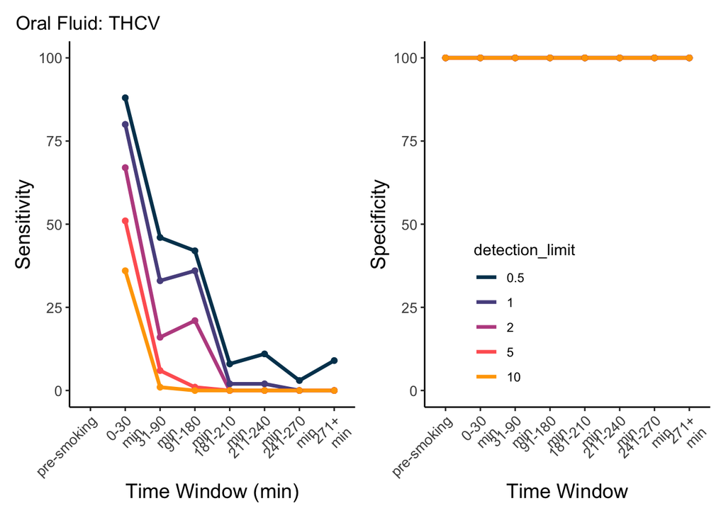

```r
plot_cutoffs(dataset=OF_ss,
             timepoint_use_variable=OF$timepoint,
             tissue="Oral Fluid",
             cpd="thcv")
```

THCV’s short detection window and rapid decline in sensitivity suggest it may be useful only for detecting immediate, post-use impairment.For roadside testing, lower cutoffs (0.5-1 ng/mL) may be necessary to capture even brief periods of detectability, but the usefulness of THCV as a standalone marker is limited due to its very short detection window.

In a conclusion,THC’s detection profile(at 5 ng/mL cutoff) in oral fluid makes it suitable for roadside testing, as it can reliably indicate recent cannabis use without the extremely short window of detectability seen with THCV.5 ng/mL cutoff provides a balance between high specificity and a reasonable detection window, capturing recent THC use while minimizing the detection of residual levels that are unlikely to indicate impairment.

Dataframe that contains the performance metrics (Sensitivity and Specificity) for multiple compounds across different cutoff levels and timepoints in breath samples:

```r
# specify which calculations to make
cutoffs <- c(0.5, 1, 2, 5, 10)
compounds <- combined_csv |> filter(fluid_type=="BR") |> filter(!is.na(value)) |> distinct(compound) |> pull(compound)
BR_timepoints <- c("pre-smoking","0-40 min","41-90 min",
                   "91-180 min", "181-210 min", "211-240 min",
                   "241-270 min", "271+ min")
BR <- cs_data |> filter(fluid_type=="BR")

# Specify all parameter combinations
param_grid <- expand.grid(
  cutoffs = cutoffs,
  compounds = compounds,
  timepoint_use = OF_timepoints,
  group = unique(OF$group)
)

# Calculate for all cutoff-compound-timepoint combinations
BR_ss <- purrr::pmap_dfr(param_grid, ~ make_calculations(dataset=BR, cutoff = ..1, compound = as.character(..2), timepoint_use = ..3, group = ..4))

BR_ss
```

```
## # A tibble: 60 × 16
##       TP    FN    FP    TN detection_limit compound time_window group        NAs
##    <dbl> <dbl> <int> <int>           <dbl> <chr>    <fct>       <fct>      <int>
##  1     0     0     6   185             0.5 thc      pre-smoking Not exper…   758
##  2     0     0     6   185             1   thc      pre-smoking Not exper…   758
##  3     0     0     6   185             2   thc      pre-smoking Not exper…   758
##  4     0     0     6   185             5   thc      pre-smoking Not exper…   758
##  5     0     0     6   185            10   thc      pre-smoking Not exper…   758
##  6    24    66     0    30             0.5 thc      91-180 min  Not exper…   829
##  7    24    66     0    30             1   thc      91-180 min  Not exper…   829
##  8    24    66     0    30             2   thc      91-180 min  Not exper…   829
##  9    24    66     0    30             5   thc      91-180 min  Not exper…   829
## 10    24    66     0    30            10   thc      91-180 min  Not exper…   829
## # ℹ 50 more rows
## # ℹ 7 more variables: N <int>, Sensitivity <dbl>, Specificity <dbl>,
## #   Youden_J <dbl>, PPV <dbl>, NPV <dbl>, Efficiency <dbl>
```

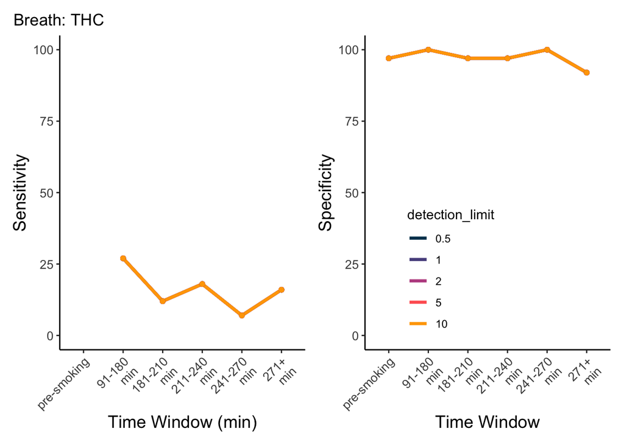

```r
plot_cutoffs(dataset=BR_ss,
             timepoint_use_variable=BR$timepoint,
             tissue="Breath",
             cpd="thc")
```

Breath testing for THC, even at a high cutoff (10 ng/mL), provides high specificity but very low sensitivity. Although sensitivity is low, the high specificity suggests that any positive THC detection in breath is almost certainly accurate. This may be beneficial in contexts where even rare positive detections could be useful, but it also implies that many THC-positive individuals might not be detected.

#### Cutoffs by User Types

Now that we have established THC in oral fluid as our chosen compound, we want to extend our analysis to see if the cutoffs should be different for frequent vs. occasional users. To do so, we will re-generate our sensitivity and specificity graphs for either groups.

First, let’s look at occasional users:

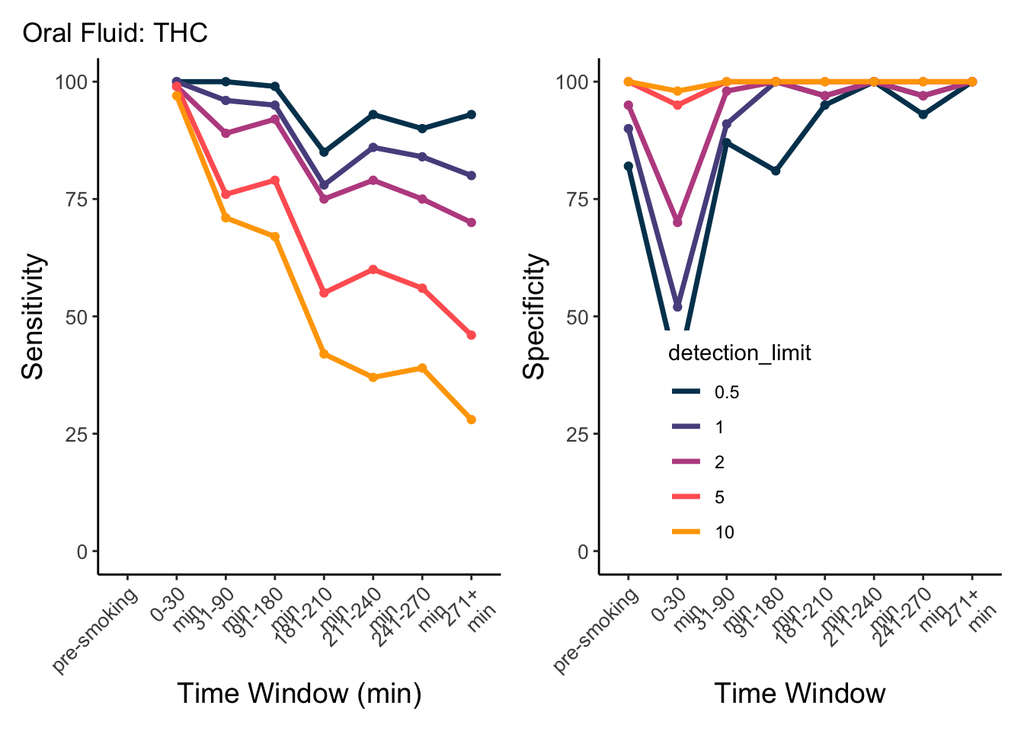

```r
occasional <- OF_ss |> filter(group=="Not experienced user")
plot_cutoffs(dataset=occasional,
             timepoint_use_variable=OF$timepoint,
             tissue="Oral Fluid",
             cpd="thc")
```

Now, let’s look at frequent users:

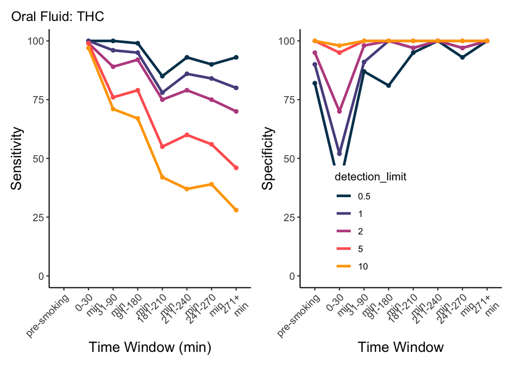

```r
frequent <- OF_ss |> filter(group=="Experienced user")
plot_cutoffs(dataset=frequent,
             timepoint_use_variable=OF$timepoint,
             tissue="Oral Fluid",
             cpd="thc")
```

## Results & Discussion

In oral fluid analysis, THC demonstrated a strong profile with high specificity and sensitivity. A 5 ng/mL cutoff in oral fluid yielded a longer detection window and lower false-positive rate, making it suitable for applications requiring immediate detection. In contrast, THCV had a very short detection window, limiting its effectiveness as a standalone indicator despite its high specificity.

For breath analysis, THC was the only detectable compound, and although it exhibited high specificity, sensitivity remained low even at high cutoffs (e.g., 10 ng/mL). This low sensitivity suggests that while positive detections in breath are highly reliable, many cases of recent use may go undetected, indicating that breath analysis alone may be insufficient as a primary detection method.

Several limitations of this study should be noted. The study design by Hubbard et al. (2021) involved participants smoking a standardized amount (a 700 mg cannabis cigarette with a minimum of four puffs), which may not accurately reflect real-world consumption patterns. The data collection window was limited to six hours post-consumption, constraining the assessment of longer-term detection patterns. The cutoff analysis also used a narrow range with only five cutoff values, potentially limiting insights into optimal sensitivity and specificity levels.

Future studies should consider a broader array of cutoffs and varied consumption methods to improve generalizability and provide more comprehensive insights into optimal sensitivity and specificity levels. Additionally, exploring combined matrix data (e.g., both oral fluid and whole blood) may aid in distinguishing between frequent and occasional users, as this study found limitations in sensitivity and specificity across these groups. The study’s focus on specific THC concentrations (5.9% and 13.4%) in a controlled setting may also limit its applicability across the broader spectrum of cannabis products used in real-world scenarios.

[^1]: https://academic.oup.com/clinchem/article/59/3/478/5621997
[^2]: https://rosap.ntl.bts.gov/view/dot/1913
[^3]: file:///Users/weijunzhi/Downloads/fpsyt-12-689444.pdf
[^4]: https://www.tandfonline.com/doi/full/10.1080/15389588.2020.1851685
[^5]: https://www.tandfonline.com/doi/full/10.1080/15389588.2020.1851685
[^6]: https://academic.oup.com/clinchem/article/59/3/519/5622035
[^7]: https://academic.oup.com/jat/article/45/8/820/6311388?login=false#303593274